# DAT200_Week2_Assignment_Zoe Jin

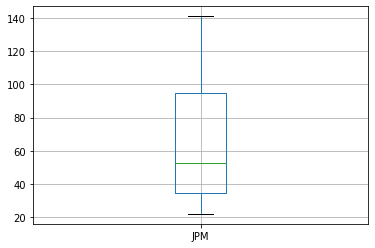

```python
price.boxplot(column=['JPM'])
```

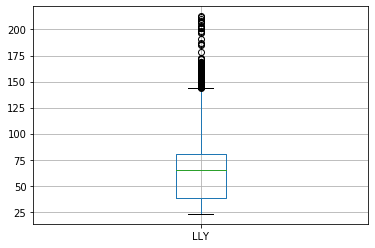

```python
price.boxplot(column=['LLY'])
```

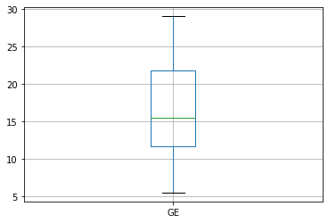

```python
price.boxplot(column=['GE'])
```

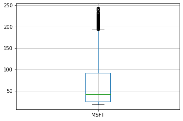

```python
price.boxplot(column=['MSFT'])
```

```python
price.describe()
```

|  | JPM | LLY | GE | MSFT |
| --- | --- | --- | --- | --- |
| count | 2793.000000 | 2793.000000 | 2793.000000 | 2793.000000 |
| mean | 63.425331 | 68.929854 | 16.741598 | 66.124832 |
| std | 30.836281 | 38.262911 | 6.229574 | 54.608301 |
| min | 21.923330 | 22.916931 | 5.467705 | 18.086349 |
| 25% | 34.724697 | 38.019775 | 11.656926 | 24.767351 |
| 50% | 52.497662 | 65.467110 | 15.492194 | 42.311794 |
| 75% | 94.704712 | 80.482994 | 21.766396 | 92.265900 |
| max | 141.169998 | 212.720001 | 29.070246 | 243.000000 |

```
array([[<matplotlib.axes._subplots.AxesSubplot object at 0x0000022478AB0908>,
      dtype=object)
```

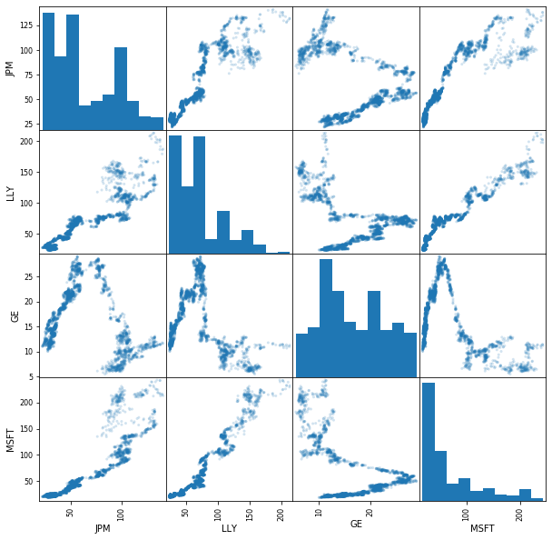

```python
scatter_matrix(price, alpha=0.2, figsize=(10, 10))
```

```python
price.corr()
```

|  | JPM | LLY | GE | MSFT |
| --- | --- | --- | --- | --- |
| JPM | 1.000000 | 0.889970 | -0.295736 | 0.877769 |
| LLY | 0.889970 | 1.000000 | -0.329425 | 0.957392 |
| GE | -0.295736 | -0.329425 | 1.000000 | -0.495065 |
| MSFT | 0.877769 | 0.957392 | -0.495065 | 1.000000 |

LLY and MSFT stocks are the most correlated and there is a positive correlation between these two stocks. JPM and GE are the least correlated and there is a negative correlation.

```python
np.var(price)
```

```
JPM      950.535798
LLY     1463.526182
GE        38.793697
MSFT    2980.998820
dtype: float64
```

MSFT has the highest variance and GE has the lowest.

```
array([[<matplotlib.axes._subplots.AxesSubplot object at 0x0000022478A35EC8>]],
      dtype=object)
```

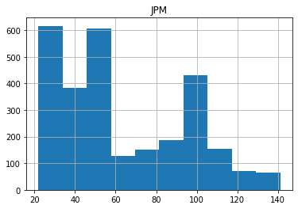

```python
price.hist(column=['JPM'],bins=10)
```

The shape of JPM is nonsymmetric, bimodal.

```
array([[<matplotlib.axes._subplots.AxesSubplot object at 0x0000022478CA4A08>]],
      dtype=object)
```

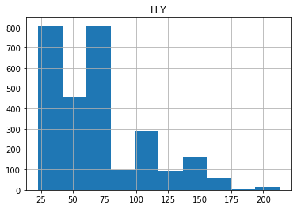

```python
price.hist(column=['LLY'],bins=10)
```

The shape of LLY is nonsymmetric, bimodel

```
array([[<matplotlib.axes._subplots.AxesSubplot object at 0x0000022478D38808>]],
      dtype=object)
```

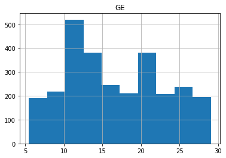

```python
price.hist(column=['GE'],bins=10)
```

The shape of GE is bimodal

```
array([[<matplotlib.axes._subplots.AxesSubplot object at 0x0000022478D9AE48>]],
      dtype=object)
```

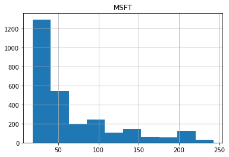

```python
price.hist(column=['MSFT'],bins=10)
```

The shape of MSFT is right-skewed, unimodal.